# Exploring Cohon’s method of calibrating boundary penalties

Kris Esturas

2025-12-01

# 1. Introduction

Boundary penalties are a commonly used in spatial conservation planning to **reduce fragmentation**. In *prioritzr*, boundary penalties encourage solutions that form compact clusters of planning units, rather than scattered selections. Compact solutions are often easier to manage and may better support ecological procceses, but they typically come at a higher cost.

A practical difficulty is that the appropriate magnitude of the boundary penalty can be **arbitrary**. If the penalty is too small, solutions remain fragmented. If it is too large, solutions can become overly compact and very expensive. In many applications, boundary penalties may be therefore chosen in an ad hoc way, with limited guidance on whether the resulting trade-off between cost and compactness is reasonable.

The function `calibrate_cohon_penalty()` in *prioritizr* provides a systematic way to address this problem. It implements **Cohon’s method of calibration** that identifies a boundary penalty intended to balance cost and compactness, based on two extreme solutions (See Section 2: A brief note on Cohon-style calibration).

In this vignette, we use the Tasmania example dataset to explore how this calibration behaves under simple, controlled changes to problem structure. Specifically, we ask:

1. How does the calibrated boundary penalty change when we **change the conservation target?**
2. Are those target–penalty relationships **consistent when feature complexity is reduced** (and in reverse order)?
3. How does the calibrated boundary penalty change when we **change the number of features?**
4. Is that feature–penalty relationship **robust to feature composition** (and in reverse order)**?**
5. What are the **speed implications** of Cohon-style calibration?

The aim is not to identify a single “correct” penalty, but to understand how sensitive the calibration is to problem structure, and what this implies for decision-support tools such as *spatialplanr* and *shinyplanr*.

# 2. A brief note on Cohon-style calibration

Very briefly, `calibrate_cohon_penalty()`:

1. Solves an “**ignore boundary**” problem (penalty ≈ 0) to find a very cheap but fragmented solution.
2. Solves a “**boundary-only**” problem (very large penalty) to find a very compact but otherwise expensive solution.
3. Uses these two “anchor” solutions (costs and boundary lengths) to compute a **boundary penalty** that trades off cost and boundary length in a more balanced way.
4. Returns this penalty so we can re-solve the problem with a **single calibrated value.**

The calibrated penalty therefore depends on how fragmented the cheap solution is and how expensive the compact solution needs to be. Thus, we will explore how altering targets or reducing the number of features affect these anchor solutions and, in turn, the calibrated penalty.

# 3. Data and baseline set-up

We use the Tasmania planning unit and feature data from *prioritizrdata*. These data represent a realistic spatial conservation planning problem and are used in other *prioritizr* examples. To keep the vignette reasonably fast, we crop the study area to a smaller subregion.

## 3.1 Load and prepare the Tasmania data

The code below loads the planning units and features, interpolates feature data onto planning units, converts features to presence-absence, and crops the study areas. Features that are absent everywhere in the cropped region are removed to avoid unnecessary computation.

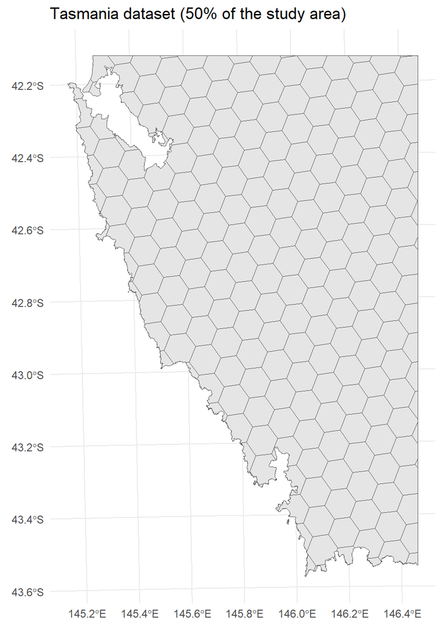

```r
# planning units
tas_pu <- get_tas_pu() %>%
mutate(cost = cost)

# features as sf
tas_features <- get_tas_features() %>%
  stars::st_as_stars() %>%
  sf::st_as_sf()

# interpolate features onto planning units
tas <- sf::st_interpolate_aw(
tas_features,
tas_pu,
extensive = FALSE,
keep_NA   = FALSE,
na.rm     = FALSE
) %>%
sf::st_join(tas_pu, join = sf::st_equals)

# identify feature columns
all_features <- tas %>%
sf::st_drop_geometry() %>%
dplyr::select(-all_of(c("id", "cost", "locked_in", "locked_out"))) %>%
names()

# convert features to binary (presence/absence)
tas <- tas |>
mutate(across(all_of(all_features), ~ if_else(.x > 0, 1, 0)))

# crop to a smaller subregion to speed up the vignette
bbox <- sf::st_bbox(tas)
frac <- 0.50

bbox_small <- bbox
bbox_small["xmax"] <- bbox["xmin"] + frac * (bbox["xmax"] - bbox["xmin"])
bbox_small["ymax"] <- bbox["ymin"] + frac * (bbox["ymax"] - bbox["ymin"])

tas_small <- sf::st_crop(tas, bbox_small)
tas <- tas_small

# drop features that are all-zero in the cropped region
feature_totals <- tas %>%
  sf::st_drop_geometry() %>%
  dplyr::select(all_of(all_features)) %>%
  dplyr::summarise(across(everything(), ~ sum(.x, na.rm = TRUE)))

zero_features <- names(feature_totals)[feature_totals[1, ] == 0]

tas <- tas %>%
  dplyr::select(-all_of(zero_features))

all_features <- setdiff(all_features, zero_features)


# plot planning units
ggplot(tas) +
  geom_sf() +
  theme_minimal() +
  labs(
    title = "Tasmania dataset (50% of the study area)",
    x = NULL, y = NULL)
```

**Note.** As this example uses only a subset of the planning area for computational efficiency, absolute results may therefore differ for the full region or the other subset of the planning area; thus, merit further experimentation.

# 4. Helper functions

To keep the analysis readable, helper functions are used to summarise solution characteristics and to standardise how problems are built, calibrated, and solved across scenarios.

## 4.1 Fragmentation and cost metrics

Each solution is summarised using a small set of interpretable metrics, including selected area, patch structure, boundary length, cost, and solver runtime.

```r
summarise_solution <- function(label,
                               solution_sf,
                               solve_time_sec,
                               min_patch_size   = NULL,
                               boundary_penalty = 0) {

# check and subset selected PUs
if (!"solution_1" %in% names(solution_sf)) {
stop("summarise_solution(): column 'solution_1' not found in solution_sf")
}

sel <- solution_sf[solution_sf$solution_1 == 1, ]
n_selected <- nrow(sel)

if (n_selected == 0) {
return(tibble(
method             = label,
n_selected         = 0L,
total_area_km2     = 0,
n_patches          = 0L,
valid_patches      = NA_integer_,
median_patch_km2   = NA_real_,
pu_cost_total      = 0,
pu_cost_mean       = NA_real_,
boundary_length_km = 0,
boundary_cost      = 0,
total_cost         = 0,
solver_time_sec    = solve_time_sec
))
}

# area of each selected PU (m²)
pu_areas_m2    <- as.numeric(sf::st_area(sel))
total_area_km2 <- sum(pu_areas_m2) / 1e6

# contiguous patches
patches <- sel |>
sf::st_union() |>
sf::st_cast("POLYGON")

patch_areas_m2   <- as.numeric(sf::st_area(patches))
n_patches        <- length(patch_areas_m2)
median_patch_km2 <- stats::median(patch_areas_m2) / 1e6

# valid patches if a minimum patch size is given
if (!is.null(min_patch_size)) {
min_patch_size_m2 <- as.numeric(min_patch_size)
valid_patches <- sum(patch_areas_m2 >= min_patch_size_m2)
} else {
valid_patches <- NA_integer_
}

# boundary length (outer boundary of patches, in km)
patch_boundaries   <- sf::st_cast(sf::st_boundary(patches), "MULTILINESTRING")
boundary_length_km <- sum(as.numeric(sf::st_length(patch_boundaries))) / 1000

# cost metrics
if (!"cost" %in% names(solution_sf)) {
stop("summarise_solution(): column 'cost' not found in solution_sf")
}

pu_cost_total <- sum(sel$cost, na.rm = TRUE)
pu_cost_mean  <- mean(sel$cost, na.rm = TRUE)

boundary_cost <- boundary_length_km * boundary_penalty
total_cost    <- pu_cost_total + boundary_cost

tibble(
method             = label,
n_selected         = n_selected,
total_area_km2     = total_area_km2,
n_patches          = n_patches,
valid_patches      = valid_patches,
median_patch_km2   = median_patch_km2,
pu_cost_total      = pu_cost_total,
pu_cost_mean       = pu_cost_mean,
boundary_length_km = boundary_length_km,
boundary_cost      = boundary_cost,
total_cost         = total_cost,
solver_time_sec    = solve_time_sec
)
}
```

## 4.2 Building and calibrating problems

Next, we define a small helper to: 1. build a *prioritizr* problem for a given **target** and a chosen set of **features**, 2. add a temporary boundary penalty, 3. run `calibrate_cohon_penalty()` to find a calibrated boundary penalty, 4. solve the problem with the calibrated penalty, and 5. return a tidy row with the penalty, timings, and solution metrics.

```r
run_cohon_experiment <- function(label, target, feature_names) {

  # ---- helper: silence CBC + any output during solver-heavy calls ----
quietly_all <- function(expr) {
  out <- tempfile(fileext = ".out.txt")
  msg <- tempfile(fileext = ".msg.txt")
  on.exit({ unlink(out); unlink(msg) }, add = TRUE)

  con_out <- file(out, open = "wt")
  sink(con_out, type = "output")
  on.exit({ sink(type = "output"); close(con_out) }, add = TRUE)

  con_msg <- file(msg, open = "wt")
  sink(con_msg, type = "message")
  on.exit({ sink(type = "message"); close(con_msg) }, add = TRUE)

  # IMPORTANT: return the value of expr
  force(expr)
}

  # build the base problem
  prob <- problem(
    x           = tas,
    features    = feature_names,
    cost_column = "cost"
  ) |>
    add_min_set_objective() |>
    add_relative_targets(target) |>
    add_binary_decisions() |>
    add_cbc_solver(
      verbose = FALSE,
      threads = 1
    )

  # add a dummy boundary penalty
  prob_bp <- prob |>
    add_boundary_penalties(penalty = 0.0001, edge_factor = 1)

  # calibrate using Cohon's method (keep this FALSE)
  calib_time <- system.time({
    cohon_penalty <- quietly_all(
      calibrate_cohon_penalty(
        prob_bp,
        approx  = TRUE,
        verbose = FALSE
      )
    )
  })

  # sanity check: must be a single finite numeric value
cohon_penalty <- as.numeric(cohon_penalty)

if (length(cohon_penalty) != 1 || !is.finite(cohon_penalty)) {
  stop("calibrate_cohon_penalty() did not return a single finite numeric penalty.")
}

  # solve the problem with the calibrated penalty
  prob_final <- prob |>
    add_boundary_penalties(penalty = cohon_penalty, edge_factor = 1)

  solve_time <- system.time({
    solution <- quietly_all(
      solve(prob_final, force = TRUE)
    )
  })

  # summarise the solution
  metrics <- summarise_solution(
    label            = label,
    solution_sf      = solution,
    solve_time_sec   = solve_time[["elapsed"]],
    min_patch_size   = NULL,
    boundary_penalty = as.numeric(cohon_penalty)
  )

  metrics |>
    mutate(
      scenario       = label,
      n_features     = length(feature_names),
      target         = target,
      cohon_penalty  = as.numeric(cohon_penalty),
      calib_time_sec = calib_time[["elapsed"]],
      total_time_sec = calib_time[["elapsed"]] + solve_time[["elapsed"]]
    )
}
```

# 5. How does the Cohon penalty change with target level?

First, we hold the **set of features constant** and only change the **target**. Here we use all features and compare targets with incremental increases of 5% from 0 to 50%.

The table and figures below focus on the calibrated penalty, runtime, and overall cost structure. Together, they show how increasing targets influence both the calibration outcome and computational effort.

### Table

```r
cohon_target_results |>
select(
scenario, n_features, target,
cohon_penalty,
calib_time_sec, solver_time_sec, total_time_sec,
boundary_length_km, boundary_cost, pu_cost_total, total_cost
) |>
arrange(target) |>
knitr::kable(
digits  = 5,
caption = "Cohon-calibrated boundary penalties for different targets (all features)."
)
```

Cohon-calibrated boundary penalties for different targets (all features).

| scenario | n_features | target | cohon_penalty | calib_time_sec | solver_time_sec | total_time_sec | boundary_length_km | boundary_cost | pu_cost_total | total_cost |
| --- | --- | --- | --- | --- | --- | --- | --- | --- | --- | --- |
| target_5 | 24 | 0.05 | 0.00027 | 35.58 | 3.86 | 39.44 | 232.6568 | 0.06387 | 407.0298 | 407.0937 |
| target_10 | 24 | 0.10 | 0.00034 | 186.86 | 5.38 | 192.24 | 318.5866 | 0.10786 | 731.1145 | 731.2224 |
| target_15 | 24 | 0.15 | 0.00057 | 230.87 | 10.39 | 241.26 | 422.1970 | 0.24154 | 1098.8366 | 1099.0781 |
| target_20 | 24 | 0.20 | 0.00079 | 251.79 | 8.78 | 260.57 | 405.6814 | 0.32099 | 1449.0116 | 1449.3326 |
| target_25 | 24 | 0.25 | 0.00160 | 177.03 | 12.91 | 189.94 | 436.7011 | 0.69773 | 1770.2070 | 1770.9048 |
| target_30 | 24 | 0.30 | 0.00096 | 220.75 | 7.02 | 227.77 | 586.0456 | 0.56517 | 2166.1124 | 2166.6776 |
| target_35 | 24 | 0.35 | 0.00136 | 88.42 | 12.55 | 100.97 | 612.8790 | 0.83302 | 2502.1134 | 2502.9464 |
| target_40 | 24 | 0.40 | 0.00135 | 34.89 | 10.53 | 45.42 | 668.4279 | 0.90541 | 2831.1005 | 2832.0059 |
| target_45 | 24 | 0.45 | 0.00142 | 27.09 | 11.55 | 38.64 | 646.7629 | 0.91963 | 3263.3127 | 3264.2323 |
| target_50 | 24 | 0.50 | 0.00137 | 17.83 | 9.50 | 27.33 | 677.2562 | 0.92923 | 3617.6423 | 3618.5715 |

**Observations**:

From the table, we can see that:

- Total_solve time varies across targets, with higher values at intermediate targets
- total_cost generally increases steadily as the target increases
- boundary_length_km generally increases with target

### Plot 1

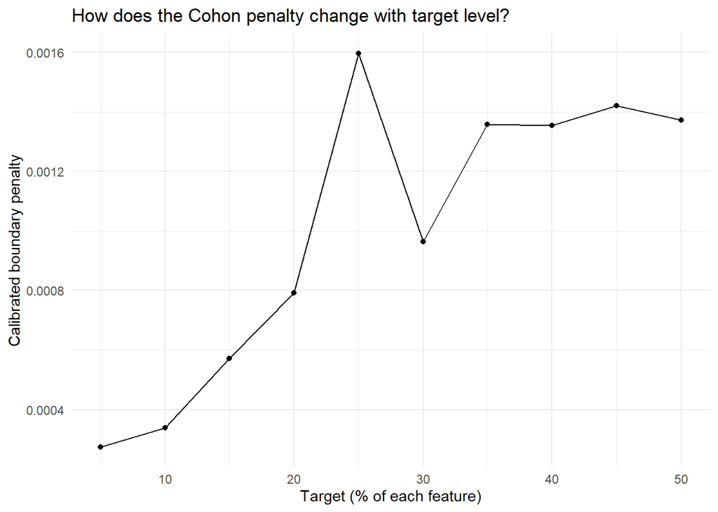

```r
ggplot(cohon_target_results,
aes(x = target * 100, y = cohon_penalty)) +
geom_line() +
geom_point() +
theme_minimal() +
labs(
x = "Target (% of each feature)",
y = "Calibrated boundary penalty",
title = "How does the Cohon penalty change with target level?"
)
```

**Observations:**

Calibrated Cohon penalties generally increase with conservation target and plateau at higher targets.

### Plot 2

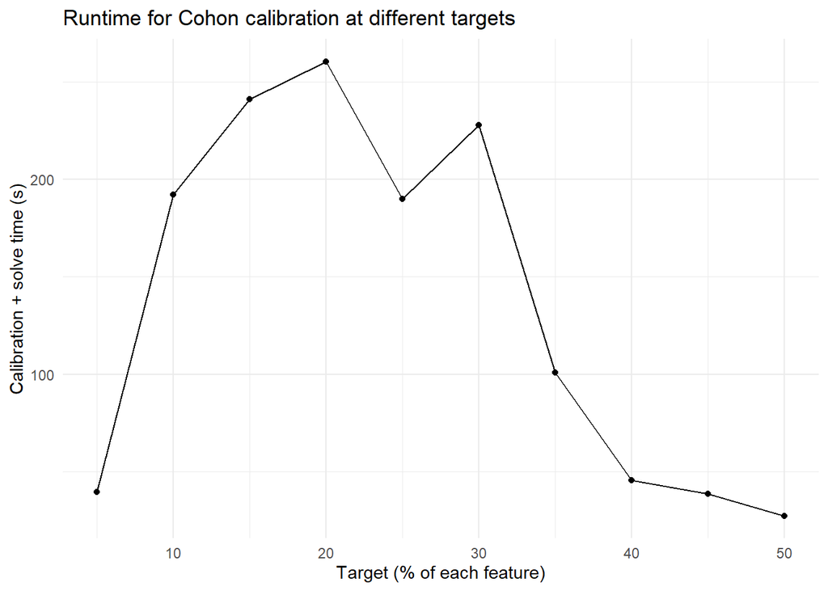

```r
ggplot(cohon_target_results,
aes(x = target * 100, y = total_time_sec)) +
geom_line() +
geom_point() +
theme_minimal() +
labs(
x = "Target (% of each feature)",
y = "Calibration + solve time (s)",
title = "Runtime for Cohon calibration at different targets"
)
```

**Observations:**

Calibration runtime peaks at intermediate targets and declines at higher targets.

# 6. Are target-penalty relationships consistent when feature complexity is reduced?

The previous section varied conservation targets while holding the feature set fixed (100% of features). Here, we assess the sensitivity of Cohon-style calibration to feature set size by repeating the target experiment across predefined feature proportions (**25%, 50%, 75%, and 100%**), with features randomly sampled within each proportion.

To assess whether the observed patterns are robust to execution order, we repeat the analysis using both forward *(Section 6.1)* and reverse target sequences *(Section 6.2)*. In our experiment, we will fix the same subset of features for the increasing target levels.

## 6.1 Forward order (25% → 100%)

```r
set.seed(123)

# feature subset proportions to test
targets <- seq(0.05, 0.50, by = 0.05)
feature_props_targets <- c(0.25, 0.50, 0.75, 1.00)
target_label <- function(t) paste0("target_", round(t * 100))
n_all <- length(all_features)

# FIXED feature subsets per proportion (reused across all targets)
feature_subsets_tbl <- purrr::map_dfr(
  feature_props_targets,
  ~{
    prop_f <- .x
    n_sub  <- max(1, floor(prop_f * n_all))

    # seed depends ONLY on feature proportion
    seed_f <- 200000 + as.integer(round(prop_f * 100))
    set.seed(seed_f)

    tibble::tibble(
      feature_prop = prop_f,
      n_features_requested = n_sub,
      seed = seed_f,
      feature_names = list(sample(all_features, size = n_sub))
    )
  }
)

# run experiment across targets, reusing the same subsets
cohon_target_results_multi <- purrr::map_dfr(
  targets,
  ~{
    t_i <- .x

    cat("\n========================================\n")
    cat("COHON CALIBRATION | TARGET =", t_i * 100, "%\n")
    cat("========================================\n")

    purrr::map_dfr(
      seq_len(nrow(feature_subsets_tbl)),
      ~{
        row_i <- feature_subsets_tbl[.x, ]
        prop_f <- row_i$feature_prop
        n_sub  <- row_i$n_features_requested
        seed_f <- row_i$seed
        feature_subset <- row_i$feature_names[[1]]

        cat("\n----------------------------------------\n")
        cat(
          sprintf(
            "Features: %.0f%% (%d of %d) | Seed: %d\n",
            prop_f * 100, n_sub, n_all, seed_f
          )
        )
        cat("----------------------------------------\n")

        run_cohon_experiment(
          label         = paste0(target_label(t_i), "_feat_", n_sub, "_of_", n_all),
          target        = t_i,
          feature_names = feature_subset
        ) |>
          dplyr::mutate(
            feature_prop = prop_f,
            n_features_requested = n_sub,
            seed = seed_f
          )
      }
    )
  }
)
```

### Table

We summarise the calibrated penalties and associated metrics across targets and feature subset sizes.

```r
cohon_target_results_multi |>
  dplyr::select(
    scenario, n_features, target,
    feature_prop, n_features_requested, seed,
    cohon_penalty,
    calib_time_sec, solver_time_sec, total_time_sec,
    boundary_length_km, boundary_cost, pu_cost_total, total_cost
  ) |>
  dplyr::arrange(target, n_features_requested) |>
  knitr::kable(
    digits  = 2,
    caption = "Cohon-calibrated penalties across target levels, using 25/50/75/100% random feature subsets."
  )
```

Cohon-calibrated penalties across target levels, using 25/50/75/100% random feature subsets.

| scenario | n_features | target | feature_prop | n_features_requested | seed | cohon_penalty | calib_time_sec | solver_time_sec | total_time_sec | boundary_length_km | boundary_cost | pu_cost_total | total_cost |
| --- | --- | --- | --- | --- | --- | --- | --- | --- | --- | --- | --- | --- | --- |
| target_5_feat_6_of_24 | 6 | 0.05 | 0.25 | 6 | 200025 | 0 | 65.57 | 3.32 | 68.89 | 165.67 | 0.08 | 356.20 | 356.28 |
| target_5_feat_12_of_24 | 12 | 0.05 | 0.50 | 12 | 200050 | 0 | 26.95 | 4.55 | 31.50 | 174.39 | 0.13 | 396.06 | 396.20 |
| target_5_feat_18_of_24 | 18 | 0.05 | 0.75 | 18 | 200075 | 0 | 40.44 | 3.81 | 44.25 | 195.39 | 0.05 | 379.79 | 379.85 |
| target_5_feat_24_of_24 | 24 | 0.05 | 1.00 | 24 | 200100 | 0 | 47.05 | 3.90 | 50.95 | 197.60 | 0.05 | 379.84 | 379.90 |
| target_10_feat_6_of_24 | 6 | 0.10 | 0.25 | 6 | 200025 | 0 | 29.33 | 1.55 | 30.88 | 239.46 | 0.06 | 667.44 | 667.50 |
| target_10_feat_12_of_24 | 12 | 0.10 | 0.50 | 12 | 200050 | 0 | 39.82 | 4.79 | 44.61 | 294.78 | 0.15 | 745.20 | 745.35 |
| target_10_feat_18_of_24 | 18 | 0.10 | 0.75 | 18 | 200075 | 0 | 110.87 | 2.99 | 113.86 | 301.79 | 0.07 | 705.64 | 705.71 |
| target_10_feat_24_of_24 | 24 | 0.10 | 1.00 | 24 | 200100 | 0 | 222.46 | 5.50 | 227.96 | 342.49 | 0.12 | 717.40 | 717.52 |
| target_15_feat_6_of_24 | 6 | 0.15 | 0.25 | 6 | 200025 | 0 | 41.89 | 3.75 | 45.64 | 250.46 | 0.18 | 1004.99 | 1005.17 |
| target_15_feat_12_of_24 | 12 | 0.15 | 0.50 | 12 | 200050 | 0 | 113.00 | 4.66 | 117.66 | 408.69 | 0.17 | 1071.42 | 1071.59 |
| target_15_feat_18_of_24 | 18 | 0.15 | 0.75 | 18 | 200075 | 0 | 180.22 | 6.70 | 186.92 | 402.12 | 0.20 | 1108.93 | 1109.14 |
| target_15_feat_24_of_24 | 24 | 0.15 | 1.00 | 24 | 200100 | 0 | 150.99 | 8.49 | 159.48 | 436.78 | 0.25 | 1112.60 | 1112.85 |
| target_20_feat_6_of_24 | 6 | 0.20 | 0.25 | 6 | 200025 | 0 | 32.75 | 2.03 | 34.78 | 308.23 | 0.15 | 1335.28 | 1335.44 |
| target_20_feat_12_of_24 | 12 | 0.20 | 0.50 | 12 | 200050 | 0 | 61.55 | 4.73 | 66.28 | 410.03 | 0.21 | 1436.91 | 1437.12 |
| target_20_feat_18_of_24 | 18 | 0.20 | 0.75 | 18 | 200075 | 0 | 180.48 | 4.05 | 184.53 | 499.52 | 0.17 | 1438.68 | 1438.85 |
| target_20_feat_24_of_24 | 24 | 0.20 | 1.00 | 24 | 200100 | 0 | 292.86 | 11.29 | 304.15 | 388.53 | 0.36 | 1439.27 | 1439.63 |
| target_25_feat_6_of_24 | 6 | 0.25 | 0.25 | 6 | 200025 | 0 | 36.63 | 1.82 | 38.45 | 392.79 | 0.17 | 1651.51 | 1651.67 |
| target_25_feat_12_of_24 | 12 | 0.25 | 0.50 | 12 | 200050 | 0 | 49.11 | 2.84 | 51.95 | 392.10 | 0.15 | 1721.98 | 1722.13 |
| target_25_feat_18_of_24 | 18 | 0.25 | 0.75 | 18 | 200075 | 0 | 230.66 | 5.96 | 236.62 | 451.04 | 0.18 | 1742.59 | 1742.77 |
| target_25_feat_24_of_24 | 24 | 0.25 | 1.00 | 24 | 200100 | 0 | 291.83 | 14.96 | 306.79 | 428.28 | 0.66 | 1788.95 | 1789.62 |
| target_30_feat_6_of_24 | 6 | 0.30 | 0.25 | 6 | 200025 | 0 | 17.27 | 2.27 | 19.54 | 470.87 | 0.17 | 2186.46 | 2186.63 |
| target_30_feat_12_of_24 | 12 | 0.30 | 0.50 | 12 | 200050 | 0 | 54.35 | 3.52 | 57.87 | 404.43 | 0.19 | 2079.60 | 2079.78 |
| target_30_feat_18_of_24 | 18 | 0.30 | 0.75 | 18 | 200075 | 0 | 65.29 | 7.67 | 72.96 | 476.43 | 0.41 | 2121.88 | 2122.29 |
| target_30_feat_24_of_24 | 24 | 0.30 | 1.00 | 24 | 200100 | 0 | 142.89 | 8.73 | 151.62 | 659.07 | 0.64 | 2115.85 | 2116.49 |
| target_35_feat_6_of_24 | 6 | 0.35 | 0.25 | 6 | 200025 | 0 | 18.25 | 3.92 | 22.17 | 461.73 | 0.46 | 2338.23 | 2338.69 |
| target_35_feat_12_of_24 | 12 | 0.35 | 0.50 | 12 | 200050 | 0 | 24.50 | 1.76 | 26.26 | 478.01 | 0.17 | 2430.14 | 2430.31 |
| target_35_feat_18_of_24 | 18 | 0.35 | 0.75 | 18 | 200075 | 0 | 54.49 | 6.80 | 61.29 | 532.06 | 0.30 | 2471.96 | 2472.27 |
| target_35_feat_24_of_24 | 24 | 0.35 | 1.00 | 24 | 200100 | 0 | 131.50 | 12.97 | 144.47 | 507.61 | 0.73 | 2522.88 | 2523.60 |
| target_40_feat_6_of_24 | 6 | 0.40 | 0.25 | 6 | 200025 | 0 | 15.61 | 4.37 | 19.98 | 389.56 | 0.49 | 2807.53 | 2808.01 |
| target_40_feat_12_of_24 | 12 | 0.40 | 0.50 | 12 | 200050 | 0 | 23.97 | 2.19 | 26.16 | 468.73 | 0.18 | 2794.99 | 2795.17 |
| target_40_feat_18_of_24 | 18 | 0.40 | 0.75 | 18 | 200075 | 0 | 43.84 | 5.97 | 49.81 | 556.96 | 0.35 | 2804.78 | 2805.13 |
| target_40_feat_24_of_24 | 24 | 0.40 | 1.00 | 24 | 200100 | 0 | 23.17 | 13.58 | 36.75 | 625.36 | 0.85 | 2903.64 | 2904.49 |
| target_45_feat_6_of_24 | 6 | 0.45 | 0.25 | 6 | 200025 | 0 | 10.95 | 3.64 | 14.59 | 463.90 | 0.53 | 3124.85 | 3125.38 |
| target_45_feat_12_of_24 | 12 | 0.45 | 0.50 | 12 | 200050 | 0 | 27.58 | 3.75 | 31.33 | 489.16 | 0.29 | 3190.91 | 3191.20 |
| target_45_feat_18_of_24 | 18 | 0.45 | 0.75 | 18 | 200075 | 0 | 25.43 | 4.77 | 30.20 | 610.19 | 0.81 | 3254.19 | 3255.00 |
| target_45_feat_24_of_24 | 24 | 0.45 | 1.00 | 24 | 200100 | 0 | 30.45 | 11.53 | 41.98 | 640.75 | 0.91 | 3247.26 | 3248.17 |
| target_50_feat_6_of_24 | 6 | 0.50 | 0.25 | 6 | 200025 | 0 | 11.05 | 3.95 | 15.00 | 471.03 | 0.51 | 3477.47 | 3477.98 |
| target_50_feat_12_of_24 | 12 | 0.50 | 0.50 | 12 | 200050 | 0 | 15.53 | 4.63 | 20.16 | 481.68 | 0.50 | 3532.15 | 3532.65 |
| target_50_feat_18_of_24 | 18 | 0.50 | 0.75 | 18 | 200075 | 0 | 10.77 | 9.89 | 20.66 | 598.95 | 0.87 | 3556.22 | 3557.10 |
| target_50_feat_24_of_24 | 24 | 0.50 | 1.00 | 24 | 200100 | 0 | 12.53 | 9.75 | 22.28 | 594.08 | 0.88 | 3556.75 | 3557.62 |

### Plot 1

The first plot shows how the calibrated penalty varies with targets for each feature proporiton.

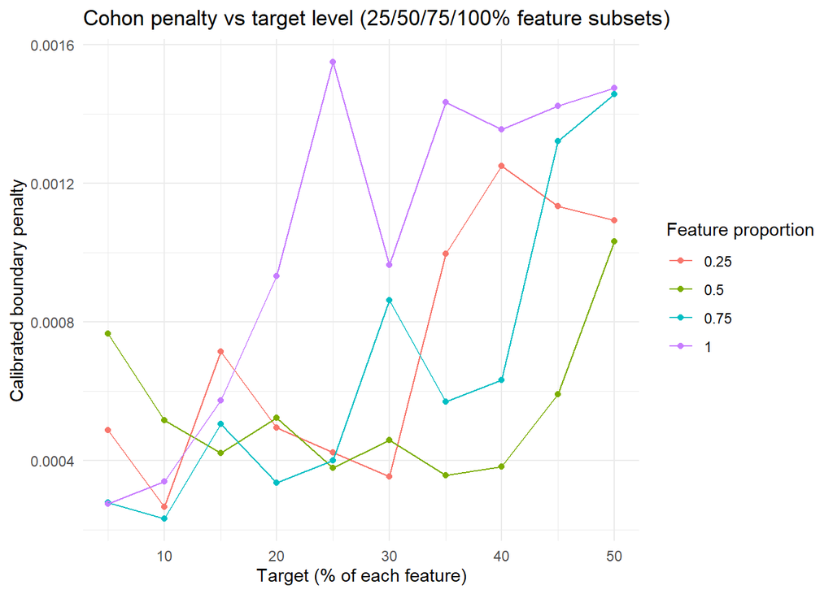

```r
# Plot 1
plot1_targets<- ggplot(
  cohon_target_results_multi,
  aes(
    x = target * 100,
    y = cohon_penalty,
    colour = factor(feature_prop),
    group  = factor(feature_prop)
  )
) +
  geom_point() +
  geom_line() +
  theme_minimal() +
  labs(
    x = "Target (% of each feature)",
    y = "Calibrated boundary penalty",
    colour = "Feature proportion",
    title = "Cohon penalty vs target level (25/50/75/100% feature subsets)"
  )
plot1_targets
```

**Observations.**

### Plot 2

The second plot shows the combined runtime (calibration+solve).

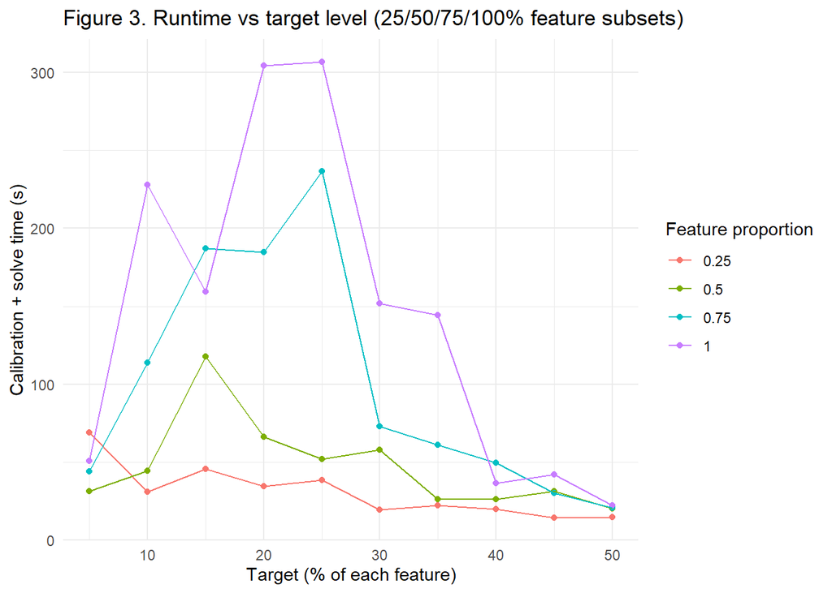

```r
# Plot 2
plot2_targets <- ggplot(
  cohon_target_results_multi,
  aes(
    x = target * 100,
    y = total_time_sec,
    colour = factor(feature_prop),
    group  = factor(feature_prop)
  )
) +
  geom_point() +
  geom_line() +
  theme_minimal() +
  labs(
    x = "Target (% of each feature)",
    y = "Calibration + solve time (s)",
    colour = "Feature proportion",
    title = "Figure 3. Runtime vs target level (25/50/75/100% feature subsets)"
  )
plot2_targets
```

**Observations:**

Runtime generally increases with the number of features included, with larger feature sets (75–100%) taking longer to solve than smaller subsets. Across all feature proportions, runtimes tend to be higher at lower to intermediate targets and decrease at higher target levels. Considerable variability is evident at intermediate targets, indicating that runtime is sensitive to both target level and feature set size rather than following a smooth or monotonic trend.

**Notes:** Because the same feature subset is held fixed across all target levels, we cannot assess whether similar patterns would emerge under alternative feature subsets with different spatial configurations.

## 6.2 Reverse order (100% → 25%)

We are now interested whether the same patterns emerge if we run the code in reverse order.

```r
targets <- seq(0.05, 0.50, by = 0.05)
targets_rev <- rev(targets)
feature_props_targets <- c(0.25, 0.50, 0.75, 1.00)
feature_props_targets_rev <- rev(feature_props_targets)
target_label <- function(t) paste0("target_", round(t * 100))
n_all <- length(all_features)

# feature subsets per proportion (reused across all targets)
feature_subsets_tbl <- purrr::map_dfr(
  feature_props_targets,
  ~{
    prop_f <- .x
    n_sub  <- max(1, floor(prop_f * n_all))

    # seed depends ONLY on feature proportion
    seed_f <- 200000 + as.integer(round(prop_f * 100))
    set.seed(seed_f)

    tibble::tibble(
      feature_prop = prop_f,
      n_features_requested = n_sub,
      seed = seed_f,
      feature_names = list(sample(all_features, size = n_sub))
    )
  }
)

cohon_target_results_multi_rev <- purrr::map_dfr(
  targets_rev,
  ~{
    t_i <- .x

    cat("\n========================================\n")
    cat("COHON CALIBRATION [REVERSE] | TARGET =", t_i * 100, "%\n")
    cat("========================================\n")

    purrr::map_dfr(
      feature_props_targets_rev,
      ~{
        prop_f <- .x

        # pull the *same* subset used in the forward run for this prop
        row_i <- dplyr::filter(feature_subsets_tbl, feature_prop == prop_f)
        stopifnot(nrow(row_i) == 1)

        n_sub <- row_i$n_features_requested[[1]]
        seed_f <- row_i$seed[[1]]
        feature_subset <- row_i$feature_names[[1]]

        cat("\n----------------------------------------\n")
        cat(sprintf(
          "[REVERSE] Features: %.0f%% (%d of %d) | Seed: %d\n",
          prop_f * 100, n_sub, n_all, seed_f
        ))
        cat("----------------------------------------\n")

        run_cohon_experiment(
          label         = paste0(target_label(t_i),
                                 "_feat_", n_sub,
                                 "_of_", n_all,
                                 "_rev"),
          target        = t_i,
          feature_names = feature_subset
        ) |>
          dplyr::mutate(
            feature_prop = prop_f,
            n_features_requested = n_sub,
            seed = seed_f,
            order = "reverse"
          )
      }
    )
  }
)
```

### Table

We summarise the calibrated penalties and associated metrics across targets and feature subset sizes.

```r
cohon_target_results_multi_rev |>
  dplyr::select(
    order,
    scenario, n_features, target,
    feature_prop, n_features_requested, seed,
    cohon_penalty,
    calib_time_sec, solver_time_sec, total_time_sec,
    boundary_length_km, boundary_cost, pu_cost_total, total_cost
  ) |>
  dplyr::arrange(target, n_features_requested) |>
  knitr::kable(
    digits  = 2,
    caption = "Cohon-calibrated penalties across target levels (reverse order only)."
  )
```

Cohon-calibrated penalties across target levels (reverse order only).

| order | scenario | n_features | target | feature_prop | n_features_requested | seed | cohon_penalty | calib_time_sec | solver_time_sec | total_time_sec | boundary_length_km | boundary_cost | pu_cost_total | total_cost |
| --- | --- | --- | --- | --- | --- | --- | --- | --- | --- | --- | --- | --- | --- | --- |
| reverse | target_5_feat_6_of_24_rev | 6 | 0.05 | 0.25 | 6 | 200025 | 0 | 65.17 | 3.30 | 68.47 | 165.67 | 0.08 | 356.20 | 356.28 |
| reverse | target_5_feat_12_of_24_rev | 12 | 0.05 | 0.50 | 12 | 200050 | 0 | 26.51 | 4.55 | 31.06 | 174.39 | 0.13 | 396.06 | 396.20 |
| reverse | target_5_feat_18_of_24_rev | 18 | 0.05 | 0.75 | 18 | 200075 | 0 | 39.84 | 3.64 | 43.48 | 195.39 | 0.05 | 379.79 | 379.85 |
| reverse | target_5_feat_24_of_24_rev | 24 | 0.05 | 1.00 | 24 | 200100 | 0 | 46.07 | 3.73 | 49.80 | 197.60 | 0.05 | 379.84 | 379.90 |
| reverse | target_10_feat_6_of_24_rev | 6 | 0.10 | 0.25 | 6 | 200025 | 0 | 28.66 | 1.51 | 30.17 | 239.46 | 0.06 | 667.44 | 667.50 |
| reverse | target_10_feat_12_of_24_rev | 12 | 0.10 | 0.50 | 12 | 200050 | 0 | 39.44 | 4.90 | 44.34 | 294.78 | 0.15 | 745.20 | 745.35 |
| reverse | target_10_feat_18_of_24_rev | 18 | 0.10 | 0.75 | 18 | 200075 | 0 | 108.32 | 2.83 | 111.15 | 301.79 | 0.07 | 705.64 | 705.71 |
| reverse | target_10_feat_24_of_24_rev | 24 | 0.10 | 1.00 | 24 | 200100 | 0 | 221.67 | 5.33 | 227.00 | 342.49 | 0.12 | 717.40 | 717.52 |
| reverse | target_15_feat_6_of_24_rev | 6 | 0.15 | 0.25 | 6 | 200025 | 0 | 42.20 | 3.75 | 45.95 | 250.46 | 0.18 | 1004.99 | 1005.17 |
| reverse | target_15_feat_12_of_24_rev | 12 | 0.15 | 0.50 | 12 | 200050 | 0 | 112.43 | 4.74 | 117.17 | 408.69 | 0.17 | 1071.42 | 1071.59 |
| reverse | target_15_feat_18_of_24_rev | 18 | 0.15 | 0.75 | 18 | 200075 | 0 | 181.24 | 6.80 | 188.04 | 402.12 | 0.20 | 1108.93 | 1109.14 |
| reverse | target_15_feat_24_of_24_rev | 24 | 0.15 | 1.00 | 24 | 200100 | 0 | 151.26 | 8.58 | 159.84 | 436.78 | 0.25 | 1112.60 | 1112.85 |
| reverse | target_20_feat_6_of_24_rev | 6 | 0.20 | 0.25 | 6 | 200025 | 0 | 33.36 | 2.00 | 35.36 | 308.23 | 0.15 | 1335.28 | 1335.44 |
| reverse | target_20_feat_12_of_24_rev | 12 | 0.20 | 0.50 | 12 | 200050 | 0 | 61.19 | 4.73 | 65.92 | 410.03 | 0.21 | 1436.91 | 1437.12 |
| reverse | target_20_feat_18_of_24_rev | 18 | 0.20 | 0.75 | 18 | 200075 | 0 | 180.42 | 4.00 | 184.42 | 499.52 | 0.17 | 1438.68 | 1438.85 |
| reverse | target_20_feat_24_of_24_rev | 24 | 0.20 | 1.00 | 24 | 200100 | 0 | 292.02 | 11.34 | 303.36 | 388.53 | 0.36 | 1439.27 | 1439.63 |
| reverse | target_25_feat_6_of_24_rev | 6 | 0.25 | 0.25 | 6 | 200025 | 0 | 37.26 | 1.80 | 39.06 | 392.79 | 0.17 | 1651.51 | 1651.67 |
| reverse | target_25_feat_12_of_24_rev | 12 | 0.25 | 0.50 | 12 | 200050 | 0 | 49.20 | 2.96 | 52.16 | 392.10 | 0.15 | 1721.98 | 1722.13 |
| reverse | target_25_feat_18_of_24_rev | 18 | 0.25 | 0.75 | 18 | 200075 | 0 | 232.83 | 6.05 | 238.88 | 451.04 | 0.18 | 1742.59 | 1742.77 |
| reverse | target_25_feat_24_of_24_rev | 24 | 0.25 | 1.00 | 24 | 200100 | 0 | 292.26 | 15.08 | 307.34 | 428.28 | 0.66 | 1788.95 | 1789.62 |
| reverse | target_30_feat_6_of_24_rev | 6 | 0.30 | 0.25 | 6 | 200025 | 0 | 17.19 | 2.17 | 19.36 | 470.87 | 0.17 | 2186.46 | 2186.63 |
| reverse | target_30_feat_12_of_24_rev | 12 | 0.30 | 0.50 | 12 | 200050 | 0 | 54.61 | 3.53 | 58.14 | 404.43 | 0.19 | 2079.60 | 2079.78 |
| reverse | target_30_feat_18_of_24_rev | 18 | 0.30 | 0.75 | 18 | 200075 | 0 | 66.06 | 7.89 | 73.95 | 476.43 | 0.41 | 2121.88 | 2122.29 |
| reverse | target_30_feat_24_of_24_rev | 24 | 0.30 | 1.00 | 24 | 200100 | 0 | 144.73 | 8.55 | 153.28 | 659.07 | 0.64 | 2115.85 | 2116.49 |
| reverse | target_35_feat_6_of_24_rev | 6 | 0.35 | 0.25 | 6 | 200025 | 0 | 18.22 | 4.03 | 22.25 | 461.73 | 0.46 | 2338.23 | 2338.69 |
| reverse | target_35_feat_12_of_24_rev | 12 | 0.35 | 0.50 | 12 | 200050 | 0 | 24.72 | 1.84 | 26.56 | 478.01 | 0.17 | 2430.14 | 2430.31 |
| reverse | target_35_feat_18_of_24_rev | 18 | 0.35 | 0.75 | 18 | 200075 | 0 | 54.96 | 6.93 | 61.89 | 532.06 | 0.30 | 2471.96 | 2472.27 |
| reverse | target_35_feat_24_of_24_rev | 24 | 0.35 | 1.00 | 24 | 200100 | 0 | 131.42 | 13.14 | 144.56 | 507.61 | 0.73 | 2522.88 | 2523.60 |
| reverse | target_40_feat_6_of_24_rev | 6 | 0.40 | 0.25 | 6 | 200025 | 0 | 15.78 | 4.37 | 20.15 | 389.56 | 0.49 | 2807.53 | 2808.01 |
| reverse | target_40_feat_12_of_24_rev | 12 | 0.40 | 0.50 | 12 | 200050 | 0 | 23.95 | 2.15 | 26.10 | 468.73 | 0.18 | 2794.99 | 2795.17 |
| reverse | target_40_feat_18_of_24_rev | 18 | 0.40 | 0.75 | 18 | 200075 | 0 | 43.25 | 5.92 | 49.17 | 556.96 | 0.35 | 2804.78 | 2805.13 |
| reverse | target_40_feat_24_of_24_rev | 24 | 0.40 | 1.00 | 24 | 200100 | 0 | 23.09 | 13.71 | 36.80 | 625.36 | 0.85 | 2903.64 | 2904.49 |
| reverse | target_45_feat_6_of_24_rev | 6 | 0.45 | 0.25 | 6 | 200025 | 0 | 11.04 | 3.62 | 14.66 | 463.90 | 0.53 | 3124.85 | 3125.38 |
| reverse | target_45_feat_12_of_24_rev | 12 | 0.45 | 0.50 | 12 | 200050 | 0 | 27.45 | 3.77 | 31.22 | 489.16 | 0.29 | 3190.91 | 3191.20 |
| reverse | target_45_feat_18_of_24_rev | 18 | 0.45 | 0.75 | 18 | 200075 | 0 | 25.23 | 4.69 | 29.92 | 610.19 | 0.81 | 3254.19 | 3255.00 |
| reverse | target_45_feat_24_of_24_rev | 24 | 0.45 | 1.00 | 24 | 200100 | 0 | 30.42 | 11.72 | 42.14 | 640.75 | 0.91 | 3247.26 | 3248.17 |
| reverse | target_50_feat_6_of_24_rev | 6 | 0.50 | 0.25 | 6 | 200025 | 0 | 11.17 | 3.96 | 15.13 | 471.03 | 0.51 | 3477.47 | 3477.98 |
| reverse | target_50_feat_12_of_24_rev | 12 | 0.50 | 0.50 | 12 | 200050 | 0 | 15.47 | 4.78 | 20.25 | 481.68 | 0.50 | 3532.15 | 3532.65 |
| reverse | target_50_feat_18_of_24_rev | 18 | 0.50 | 0.75 | 18 | 200075 | 0 | 10.55 | 9.86 | 20.41 | 598.95 | 0.87 | 3556.22 | 3557.10 |
| reverse | target_50_feat_24_of_24_rev | 24 | 0.50 | 1.00 | 24 | 200100 | 0 | 12.49 | 9.64 | 22.13 | 594.08 | 0.88 | 3556.75 | 3557.62 |

### Plot 1

Here, we plot the reverse plot together with the forward plot side by side to compare if similar trends emerge for calibrated penalties with increasing targets for different feature proportions.

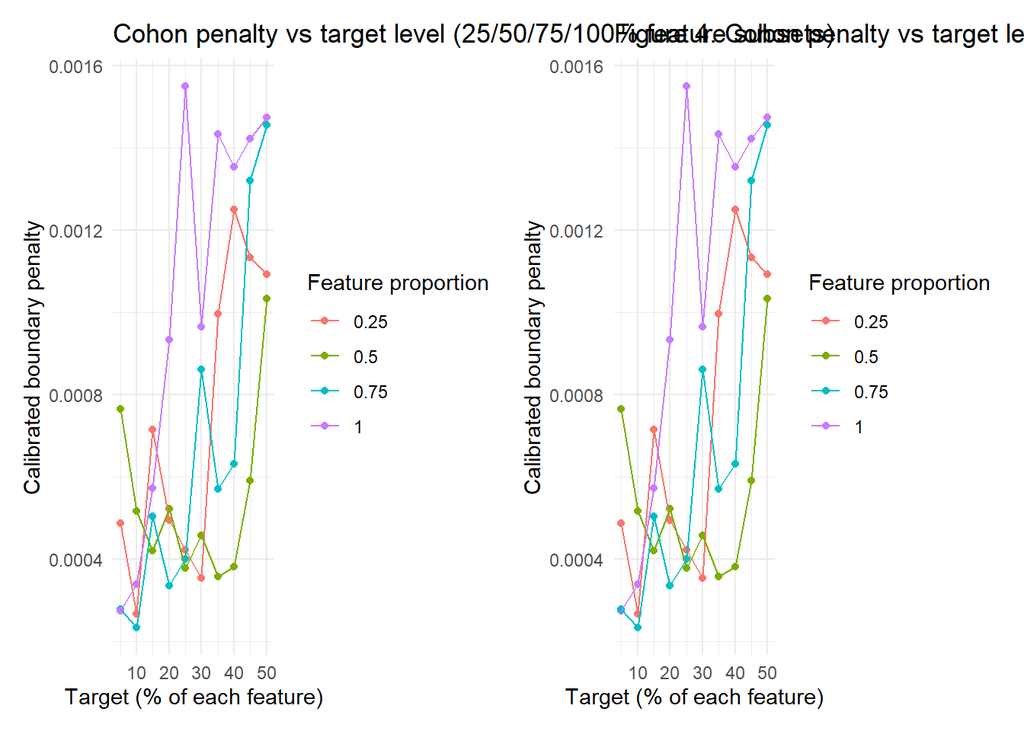

```r
# Plot 1 — penalty vs target (reverse)
plot1_targets_reverse <- ggplot(
  cohon_target_results_multi_rev,
  aes(
    x = target * 100,
    y = cohon_penalty,
    colour = factor(feature_prop),
    group  = factor(feature_prop)
  )
) +
  geom_point() +
  geom_line() +
  theme_minimal() +
  labs(
    x = "Target (% of each feature)",
    y = "Calibrated boundary penalty",
    colour = "Feature proportion",
    title = "Figure 4. Cohon penalty vs target level (25/50/75/100% feature subsets, reverse order)"
  )
plot1_targets | plot1_targets_reverse
```

**Observations**

- The resulting plots are identical.

### Plot 2

Here, we plot the reverse and forwards plots showing the runtimes.

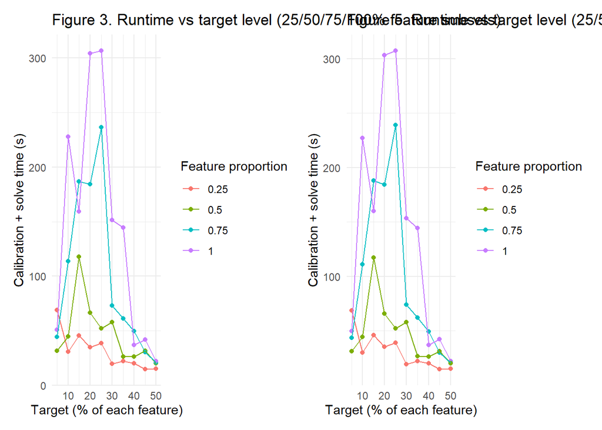

```r
plot2_targets_reverse <- ggplot(
  cohon_target_results_multi_rev,
  aes(
    x = target * 100,
    y = total_time_sec,
    colour = factor(feature_prop),
    group  = factor(feature_prop)
  )
) +
  geom_point() +
  geom_line() +
  theme_minimal() +
  labs(
    x = "Target (% of each feature)",
    y = "Calibration + solve time (s)",
    colour = "Feature proportion",
    title = "Figure 5. Runtime vs target level (25/50/75/100% feature subsets, reverse order)"
  )
plot2_targets | plot2_targets_reverse
```

**Observations:**

- The runtime plots are not identical. However, we can see that generally the same patterns emerge. Solvetimes increase from small to intermediate target levels and then dramatically decrease and stabilise as the target levels become even higher.

# 7. How does the Cohon penalty change with the number of features?

Next, we fix the **target** at 30% and vary the **number of features.**

For each feature proportion (20% to 100% in 10% increments), we run multiple replicates (20 replicates) using different random feature subsets. The subsets are chosen at random but with a fixed seed so they are reproducible.

```r
set.seed(123)

n_all <- length(all_features)

# 20%, 30%, ..., 100% of features
feature_props <- seq(0.20, 1.00, by = 0.10)

target_fixed <- 0.30
n_reps <- 20  # number of replicates

cohon_feature_results <- purrr::map_dfr(
  feature_props,
  ~{
    prop_i <- .x
    n_sub  <- max(1, floor(prop_i * n_all))

    cat("\n========================================\n")
    cat("COHON CALIBRATION | FEATURE SENSITIVITY\n")
    cat(sprintf(
      "Features: %.0f%% (%d of %d) | Target = %.0f%%\n",
      prop_i * 100, n_sub, n_all, target_fixed * 100
    ))
    cat("========================================\n")

    purrr::map_dfr(
      seq_len(n_reps),
      ~{
        rep_id <- .x

        seed_rep <- 10000 + (n_sub * 100) + rep_id
        set.seed(seed_rep)

        feature_ix     <- sample(n_all, size = n_sub)
        feature_subset <- all_features[feature_ix]

        cat("\n----------------------------------------\n")
        cat(sprintf(
          "Run %d / %d | Seed: %d\n",
          rep_id, n_reps, seed_rep
        ))
        cat("----------------------------------------\n")

        run_cohon_experiment(
          label         = paste0("features_", n_sub, "_of_", n_all, "_run_", rep_id),
          target        = target_fixed,
          feature_names = feature_subset
        ) |>
          dplyr::mutate(
            feature_prop         = prop_i,
            n_features_requested = n_sub,
            run                  = rep_id,
            seed                 = seed_rep
          )
      }
    )
  }
)
```

### Table

We summarise the calibrated penalties and associated metrics across targets and feature subset sizes.

```r
cohon_feature_results |>
  select(
    scenario, n_features, target,
    cohon_penalty,
    calib_time_sec, solver_time_sec, total_time_sec,
    boundary_length_km, boundary_cost, pu_cost_total, total_cost,
    feature_prop, run, seed
  ) |>
  arrange(n_features, run) |>
  knitr::kable(
    digits  = 2,
    caption = paste0(
      "Cohon-calibrated penalties for different numbers of features (target 30%), ",
      "with ", n_reps, " random feature-subset runs per feature count."
    )
  )
```

Cohon-calibrated penalties for different numbers of features (target 30%), with 20 random feature-subset runs per feature count.

| scenario | n_features | target | cohon_penalty | calib_time_sec | solver_time_sec | total_time_sec | boundary_length_km | boundary_cost | pu_cost_total | total_cost | feature_prop | run | seed |
| --- | --- | --- | --- | --- | --- | --- | --- | --- | --- | --- | --- | --- | --- |
| features_4_of_24_run_1 | 4 | 0.3 | 0 | 41.27 | 0.52 | 41.79 | 386.86 | 0.08 | 2046.29 | 2046.37 | 0.2 | 1 | 10401 |
| features_4_of_24_run_2 | 4 | 0.3 | 0 | 25.91 | 0.50 | 26.41 | 446.88 | 0.08 | 1954.44 | 1954.51 | 0.2 | 2 | 10402 |
| features_4_of_24_run_3 | 4 | 0.3 | 0 | 17.92 | 0.51 | 18.43 | 338.01 | 0.12 | 1866.38 | 1866.50 | 0.2 | 3 | 10403 |
| features_4_of_24_run_4 | 4 | 0.3 | 0 | 27.22 | 1.56 | 28.78 | 355.06 | 0.15 | 2150.99 | 2151.14 | 0.2 | 4 | 10404 |
| features_4_of_24_run_5 | 4 | 0.3 | 0 | 20.62 | 0.48 | 21.10 | 353.02 | 0.18 | 2063.23 | 2063.41 | 0.2 | 5 | 10405 |
| features_4_of_24_run_6 | 4 | 0.3 | 0 | 28.86 | 1.11 | 29.97 | 287.60 | 0.38 | 1186.35 | 1186.73 | 0.2 | 6 | 10406 |
| features_4_of_24_run_7 | 4 | 0.3 | 0 | 11.13 | 0.71 | 11.84 | 317.76 | 0.36 | 1216.72 | 1217.08 | 0.2 | 7 | 10407 |
| features_4_of_24_run_8 | 4 | 0.3 | 0 | 21.97 | 0.53 | 22.50 | 452.12 | 0.09 | 1869.98 | 1870.07 | 0.2 | 8 | 10408 |
| features_4_of_24_run_9 | 4 | 0.3 | 0 | 2.01 | 0.53 | 2.54 | 161.95 | 0.19 | 349.08 | 349.27 | 0.2 | 9 | 10409 |
| features_4_of_24_run_10 | 4 | 0.3 | 0 | 19.58 | 1.95 | 21.53 | 343.78 | 0.14 | 2022.33 | 2022.47 | 0.2 | 10 | 10410 |
| features_4_of_24_run_11 | 4 | 0.3 | 0 | 30.90 | 0.56 | 31.46 | 420.27 | 0.19 | 1535.33 | 1535.51 | 0.2 | 11 | 10411 |
| features_4_of_24_run_12 | 4 | 0.3 | 0 | 20.30 | 0.67 | 20.97 | 391.79 | 0.10 | 1879.05 | 1879.15 | 0.2 | 12 | 10412 |
| features_4_of_24_run_13 | 4 | 0.3 | 0 | 120.83 | 2.80 | 123.63 | 465.81 | 0.18 | 1995.31 | 1995.48 | 0.2 | 13 | 10413 |
| features_4_of_24_run_14 | 4 | 0.3 | 0 | 39.16 | 2.87 | 42.03 | 449.36 | 0.22 | 2020.59 | 2020.81 | 0.2 | 14 | 10414 |
| features_4_of_24_run_15 | 4 | 0.3 | 0 | 17.83 | 2.25 | 20.08 | 385.21 | 0.19 | 2028.43 | 2028.62 | 0.2 | 15 | 10415 |
| features_4_of_24_run_16 | 4 | 0.3 | 0 | 25.19 | 0.78 | 25.97 | 404.27 | 0.14 | 1968.30 | 1968.44 | 0.2 | 16 | 10416 |
| features_4_of_24_run_17 | 4 | 0.3 | 0 | 18.96 | 0.59 | 19.55 | 260.07 | 0.37 | 1194.31 | 1194.68 | 0.2 | 17 | 10417 |
| features_4_of_24_run_18 | 4 | 0.3 | 0 | 31.64 | 0.69 | 32.33 | 423.90 | 0.11 | 1956.19 | 1956.29 | 0.2 | 18 | 10418 |
| features_4_of_24_run_19 | 4 | 0.3 | 0 | 33.94 | 0.51 | 34.45 | 344.12 | 0.13 | 2045.31 | 2045.45 | 0.2 | 19 | 10419 |
| features_4_of_24_run_20 | 4 | 0.3 | 0 | 23.34 | 0.72 | 24.06 | 488.88 | 0.11 | 1960.30 | 1960.42 | 0.2 | 20 | 10420 |
| features_7_of_24_run_1 | 7 | 0.3 | 0 | 25.57 | 0.56 | 26.13 | 381.18 | 1.17 | 769.86 | 771.03 | 0.3 | 1 | 10701 |
| features_7_of_24_run_2 | 7 | 0.3 | 0 | 25.16 | 3.27 | 28.43 | 422.51 | 0.21 | 2053.29 | 2053.50 | 0.3 | 2 | 10702 |
| features_7_of_24_run_3 | 7 | 0.3 | 0 | 25.54 | 1.79 | 27.33 | 461.25 | 0.11 | 2015.08 | 2015.19 | 0.3 | 3 | 10703 |
| features_7_of_24_run_4 | 7 | 0.3 | 0 | 90.80 | 1.89 | 92.69 | 497.25 | 0.13 | 1995.60 | 1995.73 | 0.3 | 4 | 10704 |
| features_7_of_24_run_5 | 7 | 0.3 | 0 | 20.59 | 3.27 | 23.86 | 429.62 | 0.22 | 2040.67 | 2040.89 | 0.3 | 5 | 10705 |
| features_7_of_24_run_6 | 7 | 0.3 | 0 | 102.81 | 1.75 | 104.56 | 500.62 | 0.17 | 1941.34 | 1941.51 | 0.3 | 6 | 10706 |
| features_7_of_24_run_7 | 7 | 0.3 | 0 | 154.40 | 1.44 | 155.84 | 523.88 | 0.12 | 1986.43 | 1986.55 | 0.3 | 7 | 10707 |
| features_7_of_24_run_8 | 7 | 0.3 | 0 | 55.09 | 0.50 | 55.59 | 555.40 | 0.07 | 2008.33 | 2008.40 | 0.3 | 8 | 10708 |
| features_7_of_24_run_9 | 7 | 0.3 | 0 | 31.24 | 2.69 | 33.93 | 356.22 | 0.24 | 1997.74 | 1997.98 | 0.3 | 9 | 10709 |
| features_7_of_24_run_10 | 7 | 0.3 | 0 | 51.78 | 3.61 | 55.39 | 412.70 | 0.21 | 2004.42 | 2004.63 | 0.3 | 10 | 10710 |

[output cut: 150 more lines]

### Plot 1

The first plot shows how the calibrated boundary penalty changes as the number of features increase, while looking at different random subsets.

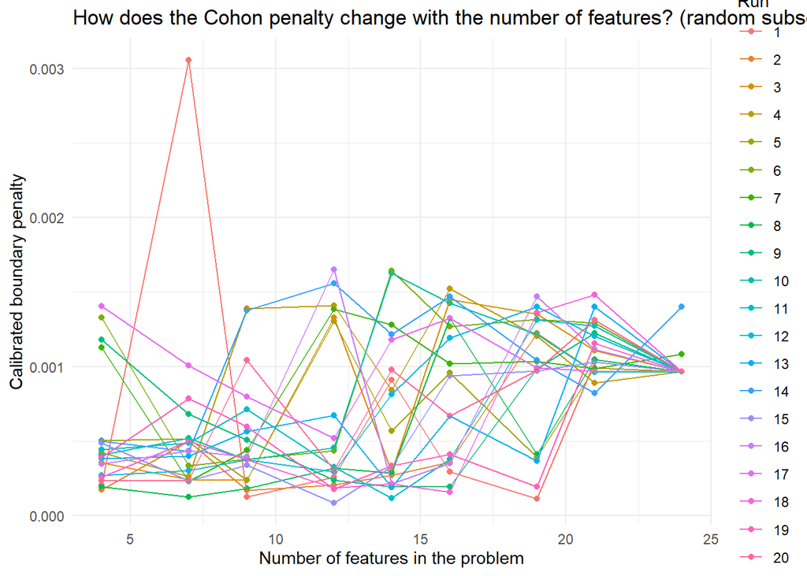

```r
# Plot
plot1_features <- ggplot(
  cohon_feature_results,
  aes(
    x = n_features,
    y = cohon_penalty,
    colour = factor(run),
    group  = factor(run)
  )
) +
  geom_point() +
  geom_line() +
  theme_minimal() +
  labs(
    x = "Number of features in the problem",
    y = "Calibrated boundary penalty",
    colour = "Run",
    title = "How does the Cohon penalty change with the number of features? (random subsets)"
  )
plot1_features
```

**Observations**:

- There is not a strict general pattern for the relationship between the calibrated boundary penalty and increasing number of features. However, it can be said that there is slight **general increase** with the calibrated penalty as the number of features increase.

### Plot 2

The plot here shows the relationship between runtimes and increasing number of features.

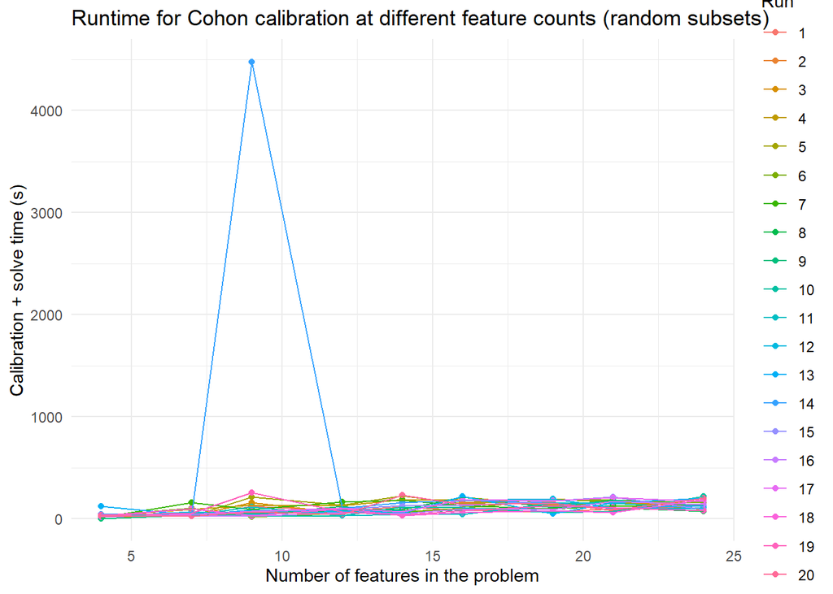

```r
# Plot
plot2_features <- ggplot(
  cohon_feature_results,
  aes(
    x = n_features,
    y = total_time_sec,

    colour = factor(run),
    group  = factor(run)
  )
) +
  geom_point() +
  geom_line() +
  theme_minimal() +
  labs(
    x = "Number of features in the problem",
    y = "Calibration + solve time (s)",
    colour = "Run",
    title = "Runtime for Cohon calibration at different feature counts (random subsets)"
  )
plot2_features
```

**Observations:**

- Due to the outlier, which shows a very long runtime, it is difficult to look at the overall pattern. Nonetheless, it can be said that the calibration time genreally increases with an increase in the number of features.

**Notes:**

To check whether evaluation order affects results, we repeat the same experiment but iterate through feature proportions in reverse order (100% down to 20%). In principle, results should be consistent given identical random seeds.

```r
set.seed(123)

n_all <- length(all_features)

# REVERSE: 100%, 90%, ..., 20% of features
feature_props <- seq(1.00, 0.20, by = -0.10)

target_fixed <- 0.30
n_reps <- 20   # number of replicates

cohon_feature_results_rev <- purrr::map_dfr(
  feature_props,
  ~{
    prop_i <- .x
    n_sub  <- max(1, floor(prop_i * n_all))

    cat("\n========================================\n")
    cat("COHON CALIBRATION [REVERSE] | FEATURE SENSITIVITY\n")
    cat(sprintf(
      "Number of features: %d/%d (%.0f%%) | Target = %.0f%%\n",
      n_sub, n_all, prop_i * 100, target_fixed * 100
    ))
    cat("========================================\n")

    purrr::map_dfr(
      rev(seq_len(n_reps)),   # 20, 19, ..., 1
      ~{
        rep_id <- .x

        # same seed logic as forward (if forward used this formula too)
        seed_rep <- 10000 + (n_sub * 100) + rep_id
        set.seed(seed_rep)

        feature_ix     <- sample(n_all, size = n_sub)
        feature_subset <- all_features[feature_ix]

        cat("\n----------------------------------------\n")
        cat(sprintf(
          "Run %d/%d | Seed: %d\n",
          rep_id, n_reps, seed_rep
        ))
        cat("----------------------------------------\n")

        run_cohon_experiment(
          label         = paste0("features_", n_sub, "_of_", n_all, "_run_", rep_id, "_rev"),
          target        = target_fixed,
          feature_names = feature_subset
        ) |>
          dplyr::mutate(
            feature_prop         = prop_i,
            n_features_requested = n_sub,
            run                  = rep_id,
            seed                 = seed_rep,
            order                = "reverse"
          )
      }
    )
  }
)
```

### Table

We summarise the calibrated penalties and associated metrics across targets and feature subset sizes.

```r
cohon_feature_results_rev |>
  select(
    scenario, n_features, target,
    cohon_penalty,
    calib_time_sec, solver_time_sec, total_time_sec,
    boundary_length_km, pu_cost_total, total_cost,
    feature_prop, run, seed, order
  ) |>
  arrange(n_features, run) |>
  knitr::kable(
    digits  = 2,
    caption = paste0(
      "REVERSE order: Cohon-calibrated penalties for different numbers of features (target 30%), ",
      "with ", n_reps, " random feature-subset runs per feature count."
    )
  )
```

REVERSE order: Cohon-calibrated penalties for different numbers of features (target 30%), with 20 random feature-subset runs per feature count.

| scenario | n_features | target | cohon_penalty | calib_time_sec | solver_time_sec | total_time_sec | boundary_length_km | pu_cost_total | total_cost | feature_prop | run | seed | order |
| --- | --- | --- | --- | --- | --- | --- | --- | --- | --- | --- | --- | --- | --- |
| features_4_of_24_run_1_rev | 4 | 0.3 | 0 | 40.34 | 0.49 | 40.83 | 386.86 | 2046.29 | 2046.37 | 0.2 | 1 | 10401 | reverse |
| features_4_of_24_run_2_rev | 4 | 0.3 | 0 | 25.77 | 0.48 | 26.25 | 446.88 | 1954.44 | 1954.51 | 0.2 | 2 | 10402 | reverse |
| features_4_of_24_run_3_rev | 4 | 0.3 | 0 | 17.95 | 0.59 | 18.54 | 338.01 | 1866.38 | 1866.50 | 0.2 | 3 | 10403 | reverse |
| features_4_of_24_run_4_rev | 4 | 0.3 | 0 | 27.62 | 1.66 | 29.28 | 355.06 | 2150.99 | 2151.14 | 0.2 | 4 | 10404 | reverse |
| features_4_of_24_run_5_rev | 4 | 0.3 | 0 | 20.80 | 0.53 | 21.33 | 353.02 | 2063.23 | 2063.41 | 0.2 | 5 | 10405 | reverse |
| features_4_of_24_run_6_rev | 4 | 0.3 | 0 | 28.81 | 1.18 | 29.99 | 287.60 | 1186.35 | 1186.73 | 0.2 | 6 | 10406 | reverse |
| features_4_of_24_run_7_rev | 4 | 0.3 | 0 | 11.13 | 0.62 | 11.75 | 317.76 | 1216.72 | 1217.08 | 0.2 | 7 | 10407 | reverse |
| features_4_of_24_run_8_rev | 4 | 0.3 | 0 | 22.16 | 0.58 | 22.74 | 452.12 | 1869.98 | 1870.07 | 0.2 | 8 | 10408 | reverse |
| features_4_of_24_run_9_rev | 4 | 0.3 | 0 | 2.34 | 0.53 | 2.87 | 161.95 | 349.08 | 349.27 | 0.2 | 9 | 10409 | reverse |
| features_4_of_24_run_10_rev | 4 | 0.3 | 0 | 19.64 | 2.06 | 21.70 | 343.78 | 2022.33 | 2022.47 | 0.2 | 10 | 10410 | reverse |
| features_4_of_24_run_11_rev | 4 | 0.3 | 0 | 30.91 | 0.61 | 31.52 | 420.27 | 1535.33 | 1535.51 | 0.2 | 11 | 10411 | reverse |
| features_4_of_24_run_12_rev | 4 | 0.3 | 0 | 20.13 | 0.71 | 20.84 | 391.79 | 1879.05 | 1879.15 | 0.2 | 12 | 10412 | reverse |
| features_4_of_24_run_13_rev | 4 | 0.3 | 0 | 120.28 | 2.78 | 123.06 | 465.81 | 1995.31 | 1995.48 | 0.2 | 13 | 10413 | reverse |
| features_4_of_24_run_14_rev | 4 | 0.3 | 0 | 38.27 | 2.77 | 41.04 | 449.36 | 2020.59 | 2020.81 | 0.2 | 14 | 10414 | reverse |
| features_4_of_24_run_15_rev | 4 | 0.3 | 0 | 17.34 | 2.14 | 19.48 | 385.21 | 2028.43 | 2028.62 | 0.2 | 15 | 10415 | reverse |
| features_4_of_24_run_16_rev | 4 | 0.3 | 0 | 24.77 | 0.84 | 25.61 | 404.27 | 1968.30 | 1968.44 | 0.2 | 16 | 10416 | reverse |
| features_4_of_24_run_17_rev | 4 | 0.3 | 0 | 18.43 | 0.61 | 19.04 | 260.07 | 1194.31 | 1194.68 | 0.2 | 17 | 10417 | reverse |
| features_4_of_24_run_18_rev | 4 | 0.3 | 0 | 30.91 | 0.67 | 31.58 | 423.90 | 1956.19 | 1956.29 | 0.2 | 18 | 10418 | reverse |
| features_4_of_24_run_19_rev | 4 | 0.3 | 0 | 33.08 | 0.52 | 33.60 | 344.12 | 2045.31 | 2045.45 | 0.2 | 19 | 10419 | reverse |
| features_4_of_24_run_20_rev | 4 | 0.3 | 0 | 22.90 | 0.77 | 23.67 | 488.88 | 1960.30 | 1960.42 | 0.2 | 20 | 10420 | reverse |
| features_7_of_24_run_1_rev | 7 | 0.3 | 0 | 24.83 | 0.56 | 25.39 | 381.18 | 769.86 | 771.03 | 0.3 | 1 | 10701 | reverse |
| features_7_of_24_run_2_rev | 7 | 0.3 | 0 | 24.60 | 3.22 | 27.82 | 422.51 | 2053.29 | 2053.50 | 0.3 | 2 | 10702 | reverse |
| features_7_of_24_run_3_rev | 7 | 0.3 | 0 | 24.83 | 1.72 | 26.55 | 461.25 | 2015.08 | 2015.19 | 0.3 | 3 | 10703 | reverse |
| features_7_of_24_run_4_rev | 7 | 0.3 | 0 | 89.15 | 1.75 | 90.90 | 497.25 | 1995.60 | 1995.73 | 0.3 | 4 | 10704 | reverse |
| features_7_of_24_run_5_rev | 7 | 0.3 | 0 | 20.20 | 3.08 | 23.28 | 429.62 | 2040.67 | 2040.89 | 0.3 | 5 | 10705 | reverse |
| features_7_of_24_run_6_rev | 7 | 0.3 | 0 | 100.66 | 1.65 | 102.31 | 500.62 | 1941.34 | 1941.51 | 0.3 | 6 | 10706 | reverse |
| features_7_of_24_run_7_rev | 7 | 0.3 | 0 | 150.05 | 1.38 | 151.43 | 523.88 | 1986.43 | 1986.55 | 0.3 | 7 | 10707 | reverse |
| features_7_of_24_run_8_rev | 7 | 0.3 | 0 | 53.31 | 0.54 | 53.85 | 555.40 | 2008.33 | 2008.40 | 0.3 | 8 | 10708 | reverse |
| features_7_of_24_run_9_rev | 7 | 0.3 | 0 | 30.55 | 2.59 | 33.14 | 356.22 | 1997.74 | 1997.98 | 0.3 | 9 | 10709 | reverse |
| features_7_of_24_run_10_rev | 7 | 0.3 | 0 | 50.31 | 3.53 | 53.84 | 412.70 | 2004.42 | 2004.63 | 0.3 | 10 | 10710 | reverse |

[output cut: 150 more lines]

### Plot 1

Here, we plot both reverse and forward orders side by side to show whether we obtain the same trend for the relationship between calibrated boundary penalty and the increasing number of features.

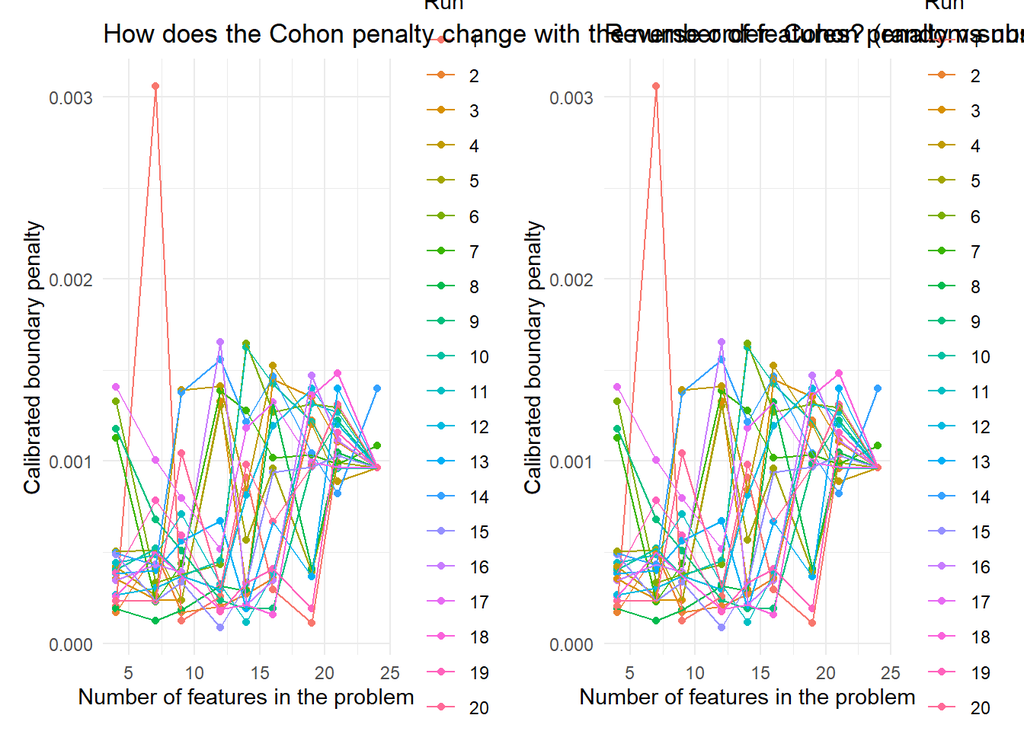

```r
# Plot
plot1_features_reverse <- ggplot(
  cohon_feature_results_rev,
  aes(
    x = n_features,
    y = cohon_penalty,
    colour = factor(run),
    group  = factor(run)
  )
) +
  geom_point() +
  geom_line() +
  theme_minimal() +
  labs(
    x = "Number of features in the problem",
    y = "Calibrated boundary penalty",
    colour = "Run",
    title = "Reverse order: Cohon penalty vs number of features (random subsets)"
  )

plot1_features | plot1_features_reverse
```

**Observations:**

- Identical plots are obtained.

### Plot 2

Here, we plot both reverse and forward orders side by side to show whether we obtain the same trend for the relationship between the runtimes and the increasing number of features.

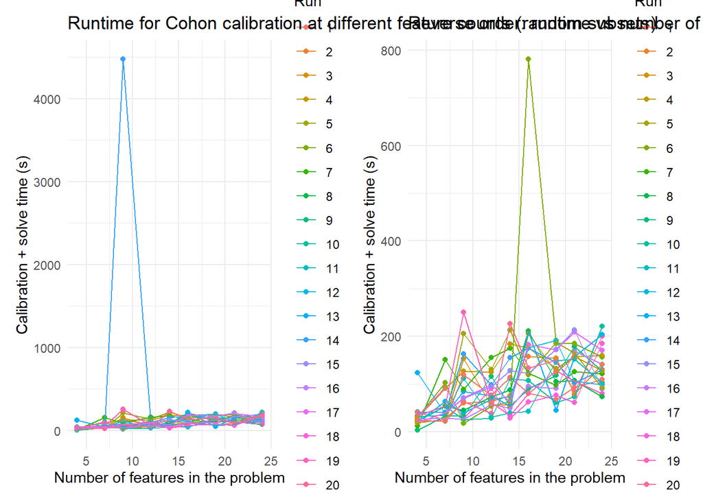

```r
# Plot
plot2_features_reverse<-ggplot(
  cohon_feature_results_rev,
  aes(
    x = n_features,
    y = total_time_sec,
    colour = factor(run),
    group  = factor(run)
  )
) +
  geom_point() +
  geom_line() +
  theme_minimal() +
  labs(
    x = "Number of features in the problem",
    y = "Calibration + solve time (s)",
    colour = "Run",
    title = "Reverse order: runtime vs number of features (random subsets)"
  )
plot2_features | plot2_features_reverse
```

# 8. Take home messages

1. Calibrated boundary penalties can change with conservation targets.
2. Penalties are sensitive to feature richness and composition because calibration responds to spatial structure.
3. Calibration introduces computational overhead that should be considered in applied planning workflows.